## **Do NFL teams need to stop the run or the pass in order to win games?**

Legendary College Football and NFL coach Chip Kelly once said, "You have to run the football and stop the run, no matter what level you play at, whether it’s high school, college or professional ranks. I’m a firm believer in that.” This idealogy that football teams need to stop the opposing team's running game is a common idea held by many NFL coaches, announcers, proffessional analysts, and fans that dates back to the origin of the game. In fact in 2013, there was a great article on the official SBNation fansite of the Dallas Cowboys detailing [the importance of defending the run.](https://www.bloggingtheboys.com/2013/9/14/4729902/the-importance-of-defending-the-run-in-a-passing-league) Due to its percieved importance there are many videos like [this](https://www.youtube.com/watch?v=7n7nS8V7L0o) made by the best NFL players detailing how and why to stop the run. Clearly defending the run has the perception of being an integral ingredient to winning football games, however, there has also been a rapidly growing belief that the NFL is becoming "a passing league". Whether its one of the leading news sources in Bleacher Report [making the claim](https://bleacherreport.com/articles/729496-nfl-has-the-nfl-really-turned-into-a-pass-first-league#:~:text=Fans%2C%20players%2C%20the%20media%20and,but%20agree%20with%20that%20logic.) or the [NFL's official site](https://www.nfl.com/news/passing-league-explaining-the-nfl-s-aerial-evolution-09000d5d82a44e69) the football world has seemingly moved toward a pass oriented era. This revolution of football thought has challenged the perception that in order to win stopping the run is of the utmost importance. With the evergrowing belief that the league revolves around the QB (Quarterback) position there is a renewed belief that teams actually need to stop the pass to win games. Teams have begun to pay premium money to [Defensive Backs](https://www.liveabout.com/what-is-a-defensive-back-1335528) in order to effectively prioritize stopping the pass. We are going to challenge both commonly held beliefs that a team needs to stop the run, and/or stop the pass by approaching the question from purely a statistical standpoint. But before we begin, for any non NFL fans or anyone new to the game of football I highly recommend checking out [this link](https://www.youtube.com/watch?v=Ddwp1HyEFRE) or [this one](https://www.youtube.com/watch?v=6vmJZBtXDuU) for a quick and easy to understand walk through of how the game works.

Now let's begin and find the answer to the question: Do NFL teams need to stop the run, the pass, or both in order to win games?

```python
import pandas as pd
import matplotlib.pyplot as plt
import seaborn as sns
import statsmodels.api as sm
from sklearn.linear_model import LinearRegression
import numpy as np
```

### **Data Scraping and Cleaning Part One**

The first step we need to accomplish is to scrape [Pro Football Reference](https://www.pro-football-reference.com/) for each NFL team's defense against Running Backs and against Quarterbacks. We can isolate rushing stats including Yards and Touchdowns by Running backs against each team to measure a team's performance against the Run and we can isolate passing stats including Yards and Touchdowns by Quarterback backs against each team to measure a team's performance against the Pass (All statistics will be used from the year 2021). Since we will be trying to see how much rushing defense and passing defense correlate to winning we will also add the amount of wins, losses, and ties each NFL team had in the 2021 season. Additionally, although the NFL playoff teams are not always teams that won more games than they [lost](https://sports.nbcsports.com/2021/01/09/how-many-teams-with-a-losing-record-have-advanced-to-the-nfl-playoffs/), since each team would rather make the playoffs with winning less games than miss the playoffs with winnning more games, we will include whether a team made the playoffs in our dataset. If the team made the playoffs in 2021 than there will be a 1 in the playoff column and if the team missed the playoffs in 2021 than there will be a 0 in the column.

```python
rushing_def = pd.read_html("https://www.pro-football-reference.com/years/2021/fantasy-points-against-RB.htm#fantasy_def")[0]
for col in rushing_def.columns:
    print(col)
```

```python
rushing_def = rushing_def.drop(columns = [('Receiving'), ('Fantasy'), ('Fantasy per Game')])
rushing_def.columns = rushing_def.columns.droplevel(0)
rushing_def
```

```python
passing_def = pd.read_html("https://www.pro-football-reference.com/years/2021/fantasy-points-against-QB.htm#fantasy_def")[0]
passing_def.info()
```

```python
passing_def = passing_def.drop(columns = [('Rushing'), ('Unnamed: 1_level_0'), ('Fantasy'), ('Fantasy per Game'), ('Unnamed: 7_level_0'), ('Unnamed: 8_level_0')])
passing_def.columns = passing_def.columns.droplevel(0)
passing_def
```

```python
rushing_def = rushing_def.rename(columns={"Att": "RushAtt", "Yds": "RushYds", "TD": "RushTD"})
rushing_def
```

```python
passing_def = passing_def.rename(columns={"Att": "PassAtt", "Yds": "PassYds", "TD": "PassTD"})
passing_def
```

```python
stats_df = pd.merge(rushing_def, passing_def, on="Tm")
stats_df
```

```python
afc_standings = pd.read_html("https://www.pro-football-reference.com/years/2021/#AFC")[0]
afc_standings
```

```python
nfc_standings = pd.read_html("https://www.pro-football-reference.com/years/2021/#NFC")[1]
nfc_standings
```

```python
standings = pd.merge(afc_standings, nfc_standings, how = 'outer')
standings.info()
```

```python
standings = standings.drop(columns = [('PF'), ('PA'), ('MoV'), ('PD'), ('SoS'), ('SRS'), ('OSRS'), ('DSRS')])
standings.head()
```

```python
standings['Tm']
df9 = []
df10 = []
for row in standings['Tm']:
  if(row[-1] == '*' or row[-1] == '+'):
    df10.append(1)
    df9.append(row[:-1])
  else:
    df10.append(0)
    df9.append(row)
```

```python
standings['Tm'] = df9
standings['Tm']
standings['Playoffs'] = df10
```

```python
stats_df = pd.merge(standings, stats_df, on="Tm")
```

```python
stats_df
```

|  | Tm | W | L | T | W-L% | Playoffs | G | RushAtt | RushYds | RushTD | Cmp | PassAtt | PassYds | PassTD | Int |
| --- | --- | --- | --- | --- | --- | --- | --- | --- | --- | --- | --- | --- | --- | --- | --- |
| 0 | Buffalo Bills | 11 | 6 | 0 | .647 | 1 | 17 | 345 | 1448 | 14 | 297 | 529 | 3047 | 12 | 19 |
| 1 | New England Patriots | 10 | 7 | 0 | .588 | 1 | 17 | 385 | 1738 | 6 | 319 | 538 | 3437 | 21 | 23 |
| 2 | Miami Dolphins | 9 | 8 | 0 | .529 | 0 | 17 | 354 | 1567 | 12 | 373 | 605 | 4251 | 23 | 14 |
| 3 | New York Jets | 4 | 13 | 0 | .235 | 0 | 17 | 437 | 1930 | 23 | 399 | 583 | 4611 | 27 | 7 |
| 4 | Cincinnati Bengals | 10 | 7 | 0 | .588 | 1 | 17 | 327 | 1412 | 13 | 419 | 625 | 4487 | 26 | 13 |
| 5 | Pittsburgh Steelers | 9 | 7 | 1 | .559 | 1 | 17 | 413 | 2054 | 13 | 355 | 562 | 3977 | 24 | 13 |
| 6 | Cleveland Browns | 8 | 9 | 0 | .471 | 0 | 17 | 350 | 1531 | 10 | 367 | 575 | 3712 | 29 | 13 |
| 7 | Baltimore Ravens | 8 | 9 | 0 | .471 | 0 | 17 | 327 | 1215 | 11 | 397 | 620 | 4986 | 31 | 9 |
| 8 | Tennessee Titans | 12 | 5 | 0 | .706 | 1 | 17 | 287 | 1087 | 9 | 395 | 627 | 4485 | 24 | 16 |
| 9 | Indianapolis Colts | 9 | 8 | 0 | .529 | 0 | 17 | 327 | 1305 | 9 | 390 | 596 | 4203 | 32 | 19 |
| 10 | Houston Texans | 4 | 13 | 0 | .235 | 0 | 17 | 428 | 2068 | 18 | 363 | 546 | 4342 | 27 | 17 |
| 11 | Jacksonville Jaguars | 3 | 14 | 0 | .176 | 0 | 17 | 411 | 1666 | 17 | 377 | 543 | 4111 | 24 | 7 |
| 12 | Kansas City Chiefs | 12 | 5 | 0 | .706 | 1 | 17 | 334 | 1550 | 7 | 398 | 606 | 4442 | 26 | 15 |
| 13 | Las Vegas Raiders | 10 | 7 | 0 | .588 | 1 | 17 | 379 | 1612 | 16 | 399 | 604 | 3980 | 29 | 6 |
| 14 | Los Angeles Chargers | 9 | 8 | 0 | .529 | 0 | 17 | 438 | 2017 | 19 | 356 | 557 | 3991 | 27 | 11 |
| 15 | Denver Broncos | 7 | 10 | 0 | .412 | 0 | 17 | 359 | 1565 | 7 | 341 | 562 | 3901 | 22 | 13 |
| 16 | Dallas Cowboys | 12 | 5 | 0 | .706 | 1 | 17 | 334 | 1455 | 8 | 362 | 608 | 4321 | 24 | 26 |
| 17 | Philadelphia Eagles | 9 | 8 | 0 | .529 | 1 | 17 | 377 | 1594 | 14 | 409 | 589 | 3976 | 28 | 12 |
| 18 | Washington Football Team | 7 | 10 | 0 | .412 | 0 | 17 | 335 | 1267 | 9 | 400 | 597 | 4520 | 34 | 11 |
| 19 | New York Giants | 4 | 13 | 0 | .235 | 0 | 17 | 426 | 1920 | 13 | 401 | 609 | 4022 | 27 | 14 |
| 20 | Green Bay Packers | 13 | 4 | 0 | .765 | 1 | 17 | 304 | 1302 | 10 | 378 | 600 | 3946 | 30 | 18 |
| 21 | Minnesota Vikings | 8 | 9 | 0 | .471 | 0 | 17 | 392 | 1751 | 12 | 400 | 625 | 4643 | 29 | 16 |
| 22 | Chicago Bears | 6 | 11 | 0 | .353 | 0 | 17 | 408 | 1833 | 9 | 314 | 477 | 3623 | 31 | 8 |
| 23 | Detroit Lions | 3 | 13 | 1 | .206 | 0 | 17 | 431 | 1930 | 18 | 359 | 543 | 4361 | 31 | 11 |
| 24 | Tampa Bay Buccaneers | 13 | 4 | 0 | .765 | 1 | 17 | 270 | 1083 | 7 | 443 | 676 | 4302 | 26 | 17 |
| 25 | New Orleans Saints | 9 | 8 | 0 | .529 | 0 | 17 | 346 | 1224 | 7 | 369 | 591 | 4131 | 20 | 18 |
| 26 | Atlanta Falcons | 7 | 10 | 0 | .412 | 0 | 17 | 412 | 1719 | 14 | 389 | 574 | 4079 | 31 | 12 |
| 27 | Carolina Panthers | 5 | 12 | 0 | .294 | 0 | 17 | 391 | 1599 | 12 | 336 | 514 | 3543 | 26 | 9 |
| 28 | Los Angeles Rams | 12 | 5 | 0 | .706 | 1 | 17 | 359 | 1334 | 11 | 414 | 622 | 4435 | 16 | 19 |
| 29 | Arizona Cardinals | 11 | 6 | 0 | .647 | 1 | 17 | 359 | 1653 | 6 | 365 | 559 | 3835 | 30 | 13 |
| 30 | San Francisco 49ers | 10 | 7 | 0 | .588 | 1 | 17 | 365 | 1303 | 13 | 369 | 540 | 3815 | 25 | 9 |
| 31 | Seattle Seahawks | 7 | 10 | 0 | .412 | 0 | 17 | 434 | 1613 | 14 | 443 | 658 | 4766 | 24 | 11 |

```python
stats_df.info()
```

```python
df7 = []
for row in stats_df['W-L%']:
  df7.append(float(row))
stats_df['W-L%'] = df7
df7 = []
for row in stats_df['W']:
  df7.append(int(row))
stats_df['W'] = df7
stats_df.info()
```

Lastly, after various different data scraping and cleaning, let's print a table of our dataset to understand the data we are working with.

```python
stats_df
```

|  | Tm | W | L | T | W-L% | Playoffs | G | RushAtt | RushYds | RushTD | Cmp | PassAtt | PassYds | PassTD | Int |
| --- | --- | --- | --- | --- | --- | --- | --- | --- | --- | --- | --- | --- | --- | --- | --- |
| 0 | Buffalo Bills | 11 | 6 | 0 | 0.647 | 1 | 17 | 345 | 1448 | 14 | 297 | 529 | 3047 | 12 | 19 |
| 1 | New England Patriots | 10 | 7 | 0 | 0.588 | 1 | 17 | 385 | 1738 | 6 | 319 | 538 | 3437 | 21 | 23 |
| 2 | Miami Dolphins | 9 | 8 | 0 | 0.529 | 0 | 17 | 354 | 1567 | 12 | 373 | 605 | 4251 | 23 | 14 |
| 3 | New York Jets | 4 | 13 | 0 | 0.235 | 0 | 17 | 437 | 1930 | 23 | 399 | 583 | 4611 | 27 | 7 |
| 4 | Cincinnati Bengals | 10 | 7 | 0 | 0.588 | 1 | 17 | 327 | 1412 | 13 | 419 | 625 | 4487 | 26 | 13 |
| 5 | Pittsburgh Steelers | 9 | 7 | 1 | 0.559 | 1 | 17 | 413 | 2054 | 13 | 355 | 562 | 3977 | 24 | 13 |
| 6 | Cleveland Browns | 8 | 9 | 0 | 0.471 | 0 | 17 | 350 | 1531 | 10 | 367 | 575 | 3712 | 29 | 13 |
| 7 | Baltimore Ravens | 8 | 9 | 0 | 0.471 | 0 | 17 | 327 | 1215 | 11 | 397 | 620 | 4986 | 31 | 9 |
| 8 | Tennessee Titans | 12 | 5 | 0 | 0.706 | 1 | 17 | 287 | 1087 | 9 | 395 | 627 | 4485 | 24 | 16 |
| 9 | Indianapolis Colts | 9 | 8 | 0 | 0.529 | 0 | 17 | 327 | 1305 | 9 | 390 | 596 | 4203 | 32 | 19 |
| 10 | Houston Texans | 4 | 13 | 0 | 0.235 | 0 | 17 | 428 | 2068 | 18 | 363 | 546 | 4342 | 27 | 17 |
| 11 | Jacksonville Jaguars | 3 | 14 | 0 | 0.176 | 0 | 17 | 411 | 1666 | 17 | 377 | 543 | 4111 | 24 | 7 |
| 12 | Kansas City Chiefs | 12 | 5 | 0 | 0.706 | 1 | 17 | 334 | 1550 | 7 | 398 | 606 | 4442 | 26 | 15 |
| 13 | Las Vegas Raiders | 10 | 7 | 0 | 0.588 | 1 | 17 | 379 | 1612 | 16 | 399 | 604 | 3980 | 29 | 6 |
| 14 | Los Angeles Chargers | 9 | 8 | 0 | 0.529 | 0 | 17 | 438 | 2017 | 19 | 356 | 557 | 3991 | 27 | 11 |
| 15 | Denver Broncos | 7 | 10 | 0 | 0.412 | 0 | 17 | 359 | 1565 | 7 | 341 | 562 | 3901 | 22 | 13 |
| 16 | Dallas Cowboys | 12 | 5 | 0 | 0.706 | 1 | 17 | 334 | 1455 | 8 | 362 | 608 | 4321 | 24 | 26 |
| 17 | Philadelphia Eagles | 9 | 8 | 0 | 0.529 | 1 | 17 | 377 | 1594 | 14 | 409 | 589 | 3976 | 28 | 12 |
| 18 | Washington Football Team | 7 | 10 | 0 | 0.412 | 0 | 17 | 335 | 1267 | 9 | 400 | 597 | 4520 | 34 | 11 |
| 19 | New York Giants | 4 | 13 | 0 | 0.235 | 0 | 17 | 426 | 1920 | 13 | 401 | 609 | 4022 | 27 | 14 |
| 20 | Green Bay Packers | 13 | 4 | 0 | 0.765 | 1 | 17 | 304 | 1302 | 10 | 378 | 600 | 3946 | 30 | 18 |
| 21 | Minnesota Vikings | 8 | 9 | 0 | 0.471 | 0 | 17 | 392 | 1751 | 12 | 400 | 625 | 4643 | 29 | 16 |
| 22 | Chicago Bears | 6 | 11 | 0 | 0.353 | 0 | 17 | 408 | 1833 | 9 | 314 | 477 | 3623 | 31 | 8 |
| 23 | Detroit Lions | 3 | 13 | 1 | 0.206 | 0 | 17 | 431 | 1930 | 18 | 359 | 543 | 4361 | 31 | 11 |
| 24 | Tampa Bay Buccaneers | 13 | 4 | 0 | 0.765 | 1 | 17 | 270 | 1083 | 7 | 443 | 676 | 4302 | 26 | 17 |
| 25 | New Orleans Saints | 9 | 8 | 0 | 0.529 | 0 | 17 | 346 | 1224 | 7 | 369 | 591 | 4131 | 20 | 18 |
| 26 | Atlanta Falcons | 7 | 10 | 0 | 0.412 | 0 | 17 | 412 | 1719 | 14 | 389 | 574 | 4079 | 31 | 12 |
| 27 | Carolina Panthers | 5 | 12 | 0 | 0.294 | 0 | 17 | 391 | 1599 | 12 | 336 | 514 | 3543 | 26 | 9 |
| 28 | Los Angeles Rams | 12 | 5 | 0 | 0.706 | 1 | 17 | 359 | 1334 | 11 | 414 | 622 | 4435 | 16 | 19 |
| 29 | Arizona Cardinals | 11 | 6 | 0 | 0.647 | 1 | 17 | 359 | 1653 | 6 | 365 | 559 | 3835 | 30 | 13 |
| 30 | San Francisco 49ers | 10 | 7 | 0 | 0.588 | 1 | 17 | 365 | 1303 | 13 | 369 | 540 | 3815 | 25 | 9 |
| 31 | Seattle Seahawks | 7 | 10 | 0 | 0.412 | 0 | 17 | 434 | 1613 | 14 | 443 | 658 | 4766 | 24 | 11 |

### **Data Analysis Part 1**

##### **Stopping the Pass**

We will begin our analysis by creating two scatter plots, one between each team's wins and passing yards allowed and the second between each team's wins and their passing touchdown's allowed. This will be a strong metric to show how each team's success stopping the pass (by limiting the passing yards or touchdowns of their opponent) effects their winning. The teams within the best third of the league in limiting passing yards/touchdowns will be displayed in green, the worst third in red, and the middle third in a neutral blue. We will also draw a linear regression line on each scatter plot that a line of best fit for the data.

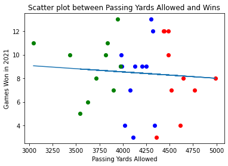

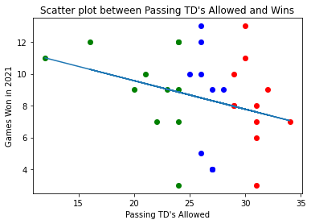

```python
col = []
for i in range(0, len(stats_df)):
    if stats_df['PassYds'][i] <= 3976:
        col.append('green')
    elif(stats_df['PassYds'][i] >= 4350):
        col.append('red')
    else:
        col.append('blue')
x = stats_df['PassYds']
y = stats_df['W']
area = 40

for i in range(len(x)):
  plt.scatter(x[i], y[i], c = col[i], s = 50,
                linewidth = 0)
m, b = np.polyfit(x, y, 1)
plt.plot(x, m*x + b)
plt.title('Scatter plot between Passing Yards Allowed and Wins')
plt.xlabel('Passing Yards Allowed')
plt.ylabel('Games Won in 2021')
plt.show()


#Passing Touchdowns
col = []
for i in range(0, len(stats_df)):
    if stats_df['PassTD'][i] <= 24:
        col.append('green')
    elif(stats_df['PassTD'][i] >= 29):
        col.append('red')
    else:
        col.append('blue')
x = stats_df['PassTD']
y = stats_df['W']
area = 40

for i in range(len(x)):
  plt.scatter(x[i], y[i], c = col[i], s = 50,
                linewidth = 0)
m, b = np.polyfit(x, y, 1)
plt.plot(x, m*x + b)
plt.title('Scatter plot between Passing TD\'s Allowed and Wins')
plt.xlabel('Passing TD\'s Allowed')
plt.ylabel('Games Won in 2021')
plt.show()
```

Upon examining the Scatter plots and regression lines, there appears to be either no or an extremely weak correlation between passing yards a team allows and winning, this would seem to support the belief that stopping the pass is not integral to winning NFL games. However there does seem to be a linear trend when it comes to the scatter plot between passing touchdowns allowed and wins, this could support the theory that NFL teams need to stop the pass, however the correlation does not look to be super strong so let's take a deeper look. Let's create a OLS Regression model. This will allow us to see whether Passing Yards or Touchdowns have an effect on Winning. We will create 2 OLS Regression models, with one focused on Passing Yards Allowed and the other Passing Touchdowns Allowed, while the winnning percentage of each team will be the dependent variables.

```python
x = stats_df['PassYds']
y = stats_df['W-L%']
x = sm.add_constant(x)
result = sm.OLS(y, x).fit()
print(result.summary())


x = stats_df['PassTD']
y = stats_df['W-L%']
x = sm.add_constant(x)
result = sm.OLS(y, x).fit()
print(result.summary())
```

```
                            OLS Regression Results
==============================================================================
Dep. Variable:                   W-L%   R-squared:                       0.006
Model:                            OLS   Adj. R-squared:                 -0.027
Method:                 Least Squares   F-statistic:                    0.1725
Date:                Mon, 16 May 2022   Prob (F-statistic):              0.681
Time:                        19:56:54   Log-Likelihood:                 11.971
No. Observations:                  32   AIC:                            -19.94
Df Residuals:                      30   BIC:                            -17.01
Df Model:                           1
Covariance Type:            nonrobust
==============================================================================
                 coef    std err          t      P>|t|      [0.025      0.975]
------------------------------------------------------------------------------
const          0.6292      0.313      2.013      0.053      -0.009       1.268
PassYds    -3.126e-05   7.53e-05     -0.415      0.681      -0.000       0.000
==============================================================================
Omnibus:                        1.724   Durbin-Watson:                   2.153
Prob(Omnibus):                  0.422   Jarque-Bera (JB):                1.340
Skew:                          -0.302   Prob(JB):                        0.512
Kurtosis:                       2.200   Cond. No.                     4.27e+04
==============================================================================

Warnings:
[1] Standard Errors assume that the covariance matrix of the errors is correctly specified.
[2] The condition number is large, 4.27e+04. This might indicate that there are
strong multicollinearity or other numerical problems.
                            OLS Regression Results
==============================================================================
Dep. Variable:                   W-L%   R-squared:                       0.081
Model:                            OLS   Adj. R-squared:                  0.051
Method:                 Least Squares   F-statistic:                     2.652
Date:                Mon, 16 May 2022   Prob (F-statistic):              0.114
Time:                        19:56:54   Log-Likelihood:                 13.235
No. Observations:                  32   AIC:                            -22.47
Df Residuals:                      30   BIC:                            -19.54
Df Model:                           1
Covariance Type:            nonrobust
==============================================================================
                 coef    std err          t      P>|t|      [0.025      0.975]
------------------------------------------------------------------------------
const          0.7717      0.169      4.556      0.000       0.426       1.118
PassTD        -0.0104      0.006     -1.628      0.114      -0.023       0.003
==============================================================================
Omnibus:                        0.787   Durbin-Watson:                   2.249
Prob(Omnibus):                  0.675   Jarque-Bera (JB):                0.845
Skew:                          -0.308   Prob(JB):                        0.655
Kurtosis:                       2.496   Cond. No.                         154.
==============================================================================

Warnings:
[1] Standard Errors assume that the covariance matrix of the errors is correctly specified.
```

##### **Stopping the Run**

We will continue our analysis by creating two more scatter plots, this time with one between each team's wins and rushing yards allowed and the second between each team's wins and their rushing touchdown's allowed. For the same reasons as the passing statistics his will be a strong metric to show how each team's success stopping the run (by limiting the rushing yards or touchdowns of their opponent) effects their winning. The teams within the best third of the league in limiting rushing yards/touchdowns will be displayed in green, the worst third in red, and the middle third in a neutral blue. We will also draw a linear regression line on each scatter plot that a line of best fit for the data.

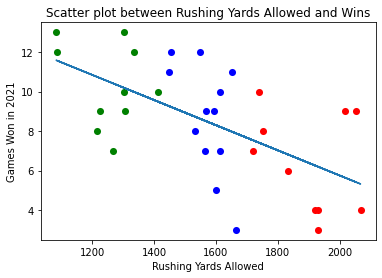

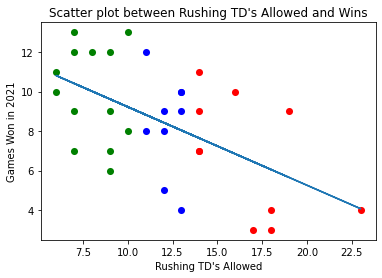

```python
col = []
for i in range(0, len(stats_df)):
    if stats_df['RushYds'][i] <= 1425:
        col.append('green')
    elif(stats_df['RushYds'][i] >= 1700):
        col.append('red')
    else:
        col.append('blue')
x = stats_df['RushYds']
y = stats_df['W']
area = 40

for i in range(len(x)):
  plt.scatter(x[i], y[i], c = col[i], s = 50,
                linewidth = 0)
m, b = np.polyfit(x, y, 1)
plt.plot(x, m*x + b)
plt.title('Scatter plot between Rushing Yards Allowed and Wins')
plt.xlabel('Rushing Yards Allowed')
plt.ylabel('Games Won in 2021')
plt.show()


col = []
for i in range(0, len(stats_df)):
    if stats_df['RushTD'][i] <= 10:
        col.append('green')
    elif(stats_df['RushTD'][i] >= 14):
        col.append('red')
    else:
        col.append('blue')
x = stats_df['RushTD']
y = stats_df['W']
area = 40

for i in range(len(x)):
  plt.scatter(x[i], y[i], c = col[i], s = 50,
                linewidth = 0)
m, b = np.polyfit(x, y, 1)
plt.plot(x, m*x + b)
plt.title('Scatter plot between Rushing TD\'s Allowed and Wins')
plt.xlabel('Rushing TD\'s Allowed')
plt.ylabel('Games Won in 2021')
plt.show()
```

Upon examining the Scatter plots and regression lines, there appears to be a stronger correlation between rushing yards and touchdowns a team allows and winning, this would seem to support the belief that stopping the rush is in fact integral to winning NFL games. However, although the correlation look to be stronger than either of the passing metrics, it still is not extremely strong so once again let's take a deeper look. Let's create a OLS Regression model of each. Similar to our reasoning for passing statistics this will allow us to see whether Rushing Yards or Touchdowns have an effect on Winning. We will create 2 OLS Regression models, with one focused on Rushing Yards Allowed and the other Rushing Touchdowns Allowed, while the winnning percentage of each team will be the dependent variables.

```python
x = stats_df['RushYds']
y = stats_df['W-L%']
x = sm.add_constant(x)
result = sm.OLS(y, x).fit()
print(result.summary())



x = stats_df['RushTD']
y = stats_df['W-L%']
x = sm.add_constant(x)
result = sm.OLS(y, x).fit()
print(result.summary())
```

```
                            OLS Regression Results
==============================================================================
Dep. Variable:                   W-L%   R-squared:                       0.351
Model:                            OLS   Adj. R-squared:                  0.330
Method:                 Least Squares   F-statistic:                     16.25
Date:                Mon, 16 May 2022   Prob (F-statistic):           0.000350
Time:                        19:56:56   Log-Likelihood:                 18.806
No. Observations:                  32   AIC:                            -33.61
Df Residuals:                      30   BIC:                            -30.68
Df Model:                           1
Covariance Type:            nonrobust
==============================================================================
                 coef    std err          t      P>|t|      [0.025      0.975]
------------------------------------------------------------------------------
const          1.0721      0.144      7.444      0.000       0.778       1.366
RushYds       -0.0004   9.02e-05     -4.031      0.000      -0.001      -0.000
==============================================================================
Omnibus:                        1.986   Durbin-Watson:                   2.011
Prob(Omnibus):                  0.371   Jarque-Bera (JB):                1.175
Skew:                          -0.093   Prob(JB):                        0.556
Kurtosis:                       2.080   Cond. No.                     9.37e+03
==============================================================================

Warnings:
[1] Standard Errors assume that the covariance matrix of the errors is correctly specified.
[2] The condition number is large, 9.37e+03. This might indicate that there are
strong multicollinearity or other numerical problems.
                            OLS Regression Results
==============================================================================
Dep. Variable:                   W-L%   R-squared:                       0.316
Model:                            OLS   Adj. R-squared:                  0.294
Method:                 Least Squares   F-statistic:                     13.89
Date:                Mon, 16 May 2022   Prob (F-statistic):           0.000804
Time:                        19:56:56   Log-Likelihood:                 17.968
No. Observations:                  32   AIC:                            -31.94
Df Residuals:                      30   BIC:                            -29.00
Df Model:                           1
Covariance Type:            nonrobust
==============================================================================
                 coef    std err          t      P>|t|      [0.025      0.975]
------------------------------------------------------------------------------
const          0.7730      0.077      9.978      0.000       0.615       0.931
RushTD        -0.0229      0.006     -3.727      0.001      -0.035      -0.010
==============================================================================
Omnibus:                        5.610   Durbin-Watson:                   2.151
Prob(Omnibus):                  0.061   Jarque-Bera (JB):                1.926
Skew:                          -0.111   Prob(JB):                        0.382
Kurtosis:                       1.819   Cond. No.                         38.9
==============================================================================

Warnings:
[1] Standard Errors assume that the covariance matrix of the errors is correctly specified.
```

Upon examination of both the OLS Linear Regression Results, it appears there is still a weak correlation between Rushing Yards Allowed and Winning Percentage as the R-squared is still low at .351, this is higher than the passing statistics but still not a strong correlation. Additionally, the connection between Rushing Touchdowns Allowed and Winning Percentage also ends up being weak as the R-squared was still low at .316. One thing to note is since the P-value of the both OLS Regression's is extremely close to 0, which are less than .05 which is our alpha or significance value and thus the relationship between Rushing Yards and Touchdowns and Winning Percentage is considered significant and the null hypothesis will be rejected. Therefore, there is a correlation between rushing statistics and winning albeit a weak one. Lastly, since the coefficient in each graph is negative it also indicates that there is a negative correlation between our variables. In essence, as a team gives up more rushing yards or touchdowns, they are less likely to win. This would support that teams need to stop the run, besides that the correlation is not strong.

### **Data Scraping and Cleaning Part Two**

Despite the lack of success showing a correlation between teams that effectively stop the run or pass and winnning, there is a deeper dive that we as data analysts can still do. Since the Data we were using was cumulative passing and rushing yards and touchdowns, the data did not account the volume of passing or rushing attempts against each team. For example, a team like the Chicago Bears was considered to be in the best third of teams against the pass, however, they encountered the least pass attempts. This may skew our data as it represents the Bears as an elite defensive team against the pass when in fact they just were not tested so thoroughly. In order to accomodate for this possible bias we will create four new columns detailing rushing/passing yards/touchdowns allowed once again, but this time per attempt.

```python
stats_df['RushYds/Att'] = stats_df['RushYds']/stats_df['RushAtt']
stats_df['PassYds/Att'] = stats_df['PassYds']/stats_df['PassAtt']
stats_df['RushTD/Att'] = stats_df['RushTD']/stats_df['RushAtt']
stats_df['PassTD/Att'] = stats_df['PassTD']/stats_df['PassAtt']
stats_df
```

|  | Tm | W | L | T | W-L% | Playoffs | G | RushAtt | RushYds | RushTD | Cmp | PassAtt | PassYds | PassTD | Int | RushYds/Att | PassYds/Att | RushTD/Att | PassTD/Att |
| --- | --- | --- | --- | --- | --- | --- | --- | --- | --- | --- | --- | --- | --- | --- | --- | --- | --- | --- | --- |
| 0 | Buffalo Bills | 11 | 6 | 0 | 0.647 | 1 | 17 | 345 | 1448 | 14 | 297 | 529 | 3047 | 12 | 19 | 4.197101 | 5.759924 | 0.040580 | 0.022684 |
| 1 | New England Patriots | 10 | 7 | 0 | 0.588 | 1 | 17 | 385 | 1738 | 6 | 319 | 538 | 3437 | 21 | 23 | 4.514286 | 6.388476 | 0.015584 | 0.039033 |
| 2 | Miami Dolphins | 9 | 8 | 0 | 0.529 | 0 | 17 | 354 | 1567 | 12 | 373 | 605 | 4251 | 23 | 14 | 4.426554 | 7.026446 | 0.033898 | 0.038017 |
| 3 | New York Jets | 4 | 13 | 0 | 0.235 | 0 | 17 | 437 | 1930 | 23 | 399 | 583 | 4611 | 27 | 7 | 4.416476 | 7.909091 | 0.052632 | 0.046312 |
| 4 | Cincinnati Bengals | 10 | 7 | 0 | 0.588 | 1 | 17 | 327 | 1412 | 13 | 419 | 625 | 4487 | 26 | 13 | 4.318043 | 7.179200 | 0.039755 | 0.041600 |
| 5 | Pittsburgh Steelers | 9 | 7 | 1 | 0.559 | 1 | 17 | 413 | 2054 | 13 | 355 | 562 | 3977 | 24 | 13 | 4.973366 | 7.076512 | 0.031477 | 0.042705 |
| 6 | Cleveland Browns | 8 | 9 | 0 | 0.471 | 0 | 17 | 350 | 1531 | 10 | 367 | 575 | 3712 | 29 | 13 | 4.374286 | 6.455652 | 0.028571 | 0.050435 |
| 7 | Baltimore Ravens | 8 | 9 | 0 | 0.471 | 0 | 17 | 327 | 1215 | 11 | 397 | 620 | 4986 | 31 | 9 | 3.715596 | 8.041935 | 0.033639 | 0.050000 |
| 8 | Tennessee Titans | 12 | 5 | 0 | 0.706 | 1 | 17 | 287 | 1087 | 9 | 395 | 627 | 4485 | 24 | 16 | 3.787456 | 7.153110 | 0.031359 | 0.038278 |
| 9 | Indianapolis Colts | 9 | 8 | 0 | 0.529 | 0 | 17 | 327 | 1305 | 9 | 390 | 596 | 4203 | 32 | 19 | 3.990826 | 7.052013 | 0.027523 | 0.053691 |
| 10 | Houston Texans | 4 | 13 | 0 | 0.235 | 0 | 17 | 428 | 2068 | 18 | 363 | 546 | 4342 | 27 | 17 | 4.831776 | 7.952381 | 0.042056 | 0.049451 |
| 11 | Jacksonville Jaguars | 3 | 14 | 0 | 0.176 | 0 | 17 | 411 | 1666 | 17 | 377 | 543 | 4111 | 24 | 7 | 4.053528 | 7.570902 | 0.041363 | 0.044199 |
| 12 | Kansas City Chiefs | 12 | 5 | 0 | 0.706 | 1 | 17 | 334 | 1550 | 7 | 398 | 606 | 4442 | 26 | 15 | 4.640719 | 7.330033 | 0.020958 | 0.042904 |
| 13 | Las Vegas Raiders | 10 | 7 | 0 | 0.588 | 1 | 17 | 379 | 1612 | 16 | 399 | 604 | 3980 | 29 | 6 | 4.253298 | 6.589404 | 0.042216 | 0.048013 |
| 14 | Los Angeles Chargers | 9 | 8 | 0 | 0.529 | 0 | 17 | 438 | 2017 | 19 | 356 | 557 | 3991 | 27 | 11 | 4.605023 | 7.165171 | 0.043379 | 0.048474 |
| 15 | Denver Broncos | 7 | 10 | 0 | 0.412 | 0 | 17 | 359 | 1565 | 7 | 341 | 562 | 3901 | 22 | 13 | 4.359331 | 6.941281 | 0.019499 | 0.039146 |
| 16 | Dallas Cowboys | 12 | 5 | 0 | 0.706 | 1 | 17 | 334 | 1455 | 8 | 362 | 608 | 4321 | 24 | 26 | 4.356287 | 7.106908 | 0.023952 | 0.039474 |
| 17 | Philadelphia Eagles | 9 | 8 | 0 | 0.529 | 1 | 17 | 377 | 1594 | 14 | 409 | 589 | 3976 | 28 | 12 | 4.228117 | 6.750424 | 0.037135 | 0.047538 |
| 18 | Washington Football Team | 7 | 10 | 0 | 0.412 | 0 | 17 | 335 | 1267 | 9 | 400 | 597 | 4520 | 34 | 11 | 3.782090 | 7.571189 | 0.026866 | 0.056951 |
| 19 | New York Giants | 4 | 13 | 0 | 0.235 | 0 | 17 | 426 | 1920 | 13 | 401 | 609 | 4022 | 27 | 14 | 4.507042 | 6.604269 | 0.030516 | 0.044335 |
| 20 | Green Bay Packers | 13 | 4 | 0 | 0.765 | 1 | 17 | 304 | 1302 | 10 | 378 | 600 | 3946 | 30 | 18 | 4.282895 | 6.576667 | 0.032895 | 0.050000 |
| 21 | Minnesota Vikings | 8 | 9 | 0 | 0.471 | 0 | 17 | 392 | 1751 | 12 | 400 | 625 | 4643 | 29 | 16 | 4.466837 | 7.428800 | 0.030612 | 0.046400 |
| 22 | Chicago Bears | 6 | 11 | 0 | 0.353 | 0 | 17 | 408 | 1833 | 9 | 314 | 477 | 3623 | 31 | 8 | 4.492647 | 7.595388 | 0.022059 | 0.064990 |
| 23 | Detroit Lions | 3 | 13 | 1 | 0.206 | 0 | 17 | 431 | 1930 | 18 | 359 | 543 | 4361 | 31 | 11 | 4.477958 | 8.031308 | 0.041763 | 0.057090 |
| 24 | Tampa Bay Buccaneers | 13 | 4 | 0 | 0.765 | 1 | 17 | 270 | 1083 | 7 | 443 | 676 | 4302 | 26 | 17 | 4.011111 | 6.363905 | 0.025926 | 0.038462 |
| 25 | New Orleans Saints | 9 | 8 | 0 | 0.529 | 0 | 17 | 346 | 1224 | 7 | 369 | 591 | 4131 | 20 | 18 | 3.537572 | 6.989848 | 0.020231 | 0.033841 |
| 26 | Atlanta Falcons | 7 | 10 | 0 | 0.412 | 0 | 17 | 412 | 1719 | 14 | 389 | 574 | 4079 | 31 | 12 | 4.172330 | 7.106272 | 0.033981 | 0.054007 |
| 27 | Carolina Panthers | 5 | 12 | 0 | 0.294 | 0 | 17 | 391 | 1599 | 12 | 336 | 514 | 3543 | 26 | 9 | 4.089514 | 6.892996 | 0.030691 | 0.050584 |
| 28 | Los Angeles Rams | 12 | 5 | 0 | 0.706 | 1 | 17 | 359 | 1334 | 11 | 414 | 622 | 4435 | 16 | 19 | 3.715877 | 7.130225 | 0.030641 | 0.025723 |
| 29 | Arizona Cardinals | 11 | 6 | 0 | 0.647 | 1 | 17 | 359 | 1653 | 6 | 365 | 559 | 3835 | 30 | 13 | 4.604457 | 6.860465 | 0.016713 | 0.053667 |
| 30 | San Francisco 49ers | 10 | 7 | 0 | 0.588 | 1 | 17 | 365 | 1303 | 13 | 369 | 540 | 3815 | 25 | 9 | 3.569863 | 7.064815 | 0.035616 | 0.046296 |
| 31 | Seattle Seahawks | 7 | 10 | 0 | 0.412 | 0 | 17 | 434 | 1613 | 14 | 443 | 658 | 4766 | 24 | 11 | 3.716590 | 7.243161 | 0.032258 | 0.036474 |

### **Data Analysis Part 2**

We will recreate our analysis once again by creating four scatter plots, between each team's wins and passing/rushing yards/touchdowns allowed, however, this time all data will be per attempt. This will be a strong metric to show how each team's success stopping the pass or run effects their winning just like in the pass just without the skewness due to lack of attempts. Once again the teams within the best third of the league in each statistic will be displayed in green, the worst third in red, and the middle third in a neutral blue. We will also draw a linear regression line on each scatter plot that a line of best fit for the data.

```python
stats_df
```

|  | Tm | W | L | T | W-L% | Playoffs | G | RushAtt | RushYds | RushTD | Cmp | PassAtt | PassYds | PassTD | Int | RushYds/Att | PassYds/Att | RushTD/Att | PassTD/Att |
| --- | --- | --- | --- | --- | --- | --- | --- | --- | --- | --- | --- | --- | --- | --- | --- | --- | --- | --- | --- |
| 0 | Buffalo Bills | 11 | 6 | 0 | 0.647 | 1 | 17 | 345 | 1448 | 14 | 297 | 529 | 3047 | 12 | 19 | 4.197101 | 5.759924 | 0.040580 | 0.022684 |
| 1 | New England Patriots | 10 | 7 | 0 | 0.588 | 1 | 17 | 385 | 1738 | 6 | 319 | 538 | 3437 | 21 | 23 | 4.514286 | 6.388476 | 0.015584 | 0.039033 |
| 2 | Miami Dolphins | 9 | 8 | 0 | 0.529 | 0 | 17 | 354 | 1567 | 12 | 373 | 605 | 4251 | 23 | 14 | 4.426554 | 7.026446 | 0.033898 | 0.038017 |
| 3 | New York Jets | 4 | 13 | 0 | 0.235 | 0 | 17 | 437 | 1930 | 23 | 399 | 583 | 4611 | 27 | 7 | 4.416476 | 7.909091 | 0.052632 | 0.046312 |
| 4 | Cincinnati Bengals | 10 | 7 | 0 | 0.588 | 1 | 17 | 327 | 1412 | 13 | 419 | 625 | 4487 | 26 | 13 | 4.318043 | 7.179200 | 0.039755 | 0.041600 |
| 5 | Pittsburgh Steelers | 9 | 7 | 1 | 0.559 | 1 | 17 | 413 | 2054 | 13 | 355 | 562 | 3977 | 24 | 13 | 4.973366 | 7.076512 | 0.031477 | 0.042705 |
| 6 | Cleveland Browns | 8 | 9 | 0 | 0.471 | 0 | 17 | 350 | 1531 | 10 | 367 | 575 | 3712 | 29 | 13 | 4.374286 | 6.455652 | 0.028571 | 0.050435 |
| 7 | Baltimore Ravens | 8 | 9 | 0 | 0.471 | 0 | 17 | 327 | 1215 | 11 | 397 | 620 | 4986 | 31 | 9 | 3.715596 | 8.041935 | 0.033639 | 0.050000 |
| 8 | Tennessee Titans | 12 | 5 | 0 | 0.706 | 1 | 17 | 287 | 1087 | 9 | 395 | 627 | 4485 | 24 | 16 | 3.787456 | 7.153110 | 0.031359 | 0.038278 |
| 9 | Indianapolis Colts | 9 | 8 | 0 | 0.529 | 0 | 17 | 327 | 1305 | 9 | 390 | 596 | 4203 | 32 | 19 | 3.990826 | 7.052013 | 0.027523 | 0.053691 |
| 10 | Houston Texans | 4 | 13 | 0 | 0.235 | 0 | 17 | 428 | 2068 | 18 | 363 | 546 | 4342 | 27 | 17 | 4.831776 | 7.952381 | 0.042056 | 0.049451 |
| 11 | Jacksonville Jaguars | 3 | 14 | 0 | 0.176 | 0 | 17 | 411 | 1666 | 17 | 377 | 543 | 4111 | 24 | 7 | 4.053528 | 7.570902 | 0.041363 | 0.044199 |
| 12 | Kansas City Chiefs | 12 | 5 | 0 | 0.706 | 1 | 17 | 334 | 1550 | 7 | 398 | 606 | 4442 | 26 | 15 | 4.640719 | 7.330033 | 0.020958 | 0.042904 |
| 13 | Las Vegas Raiders | 10 | 7 | 0 | 0.588 | 1 | 17 | 379 | 1612 | 16 | 399 | 604 | 3980 | 29 | 6 | 4.253298 | 6.589404 | 0.042216 | 0.048013 |
| 14 | Los Angeles Chargers | 9 | 8 | 0 | 0.529 | 0 | 17 | 438 | 2017 | 19 | 356 | 557 | 3991 | 27 | 11 | 4.605023 | 7.165171 | 0.043379 | 0.048474 |
| 15 | Denver Broncos | 7 | 10 | 0 | 0.412 | 0 | 17 | 359 | 1565 | 7 | 341 | 562 | 3901 | 22 | 13 | 4.359331 | 6.941281 | 0.019499 | 0.039146 |
| 16 | Dallas Cowboys | 12 | 5 | 0 | 0.706 | 1 | 17 | 334 | 1455 | 8 | 362 | 608 | 4321 | 24 | 26 | 4.356287 | 7.106908 | 0.023952 | 0.039474 |
| 17 | Philadelphia Eagles | 9 | 8 | 0 | 0.529 | 1 | 17 | 377 | 1594 | 14 | 409 | 589 | 3976 | 28 | 12 | 4.228117 | 6.750424 | 0.037135 | 0.047538 |
| 18 | Washington Football Team | 7 | 10 | 0 | 0.412 | 0 | 17 | 335 | 1267 | 9 | 400 | 597 | 4520 | 34 | 11 | 3.782090 | 7.571189 | 0.026866 | 0.056951 |
| 19 | New York Giants | 4 | 13 | 0 | 0.235 | 0 | 17 | 426 | 1920 | 13 | 401 | 609 | 4022 | 27 | 14 | 4.507042 | 6.604269 | 0.030516 | 0.044335 |
| 20 | Green Bay Packers | 13 | 4 | 0 | 0.765 | 1 | 17 | 304 | 1302 | 10 | 378 | 600 | 3946 | 30 | 18 | 4.282895 | 6.576667 | 0.032895 | 0.050000 |
| 21 | Minnesota Vikings | 8 | 9 | 0 | 0.471 | 0 | 17 | 392 | 1751 | 12 | 400 | 625 | 4643 | 29 | 16 | 4.466837 | 7.428800 | 0.030612 | 0.046400 |
| 22 | Chicago Bears | 6 | 11 | 0 | 0.353 | 0 | 17 | 408 | 1833 | 9 | 314 | 477 | 3623 | 31 | 8 | 4.492647 | 7.595388 | 0.022059 | 0.064990 |
| 23 | Detroit Lions | 3 | 13 | 1 | 0.206 | 0 | 17 | 431 | 1930 | 18 | 359 | 543 | 4361 | 31 | 11 | 4.477958 | 8.031308 | 0.041763 | 0.057090 |
| 24 | Tampa Bay Buccaneers | 13 | 4 | 0 | 0.765 | 1 | 17 | 270 | 1083 | 7 | 443 | 676 | 4302 | 26 | 17 | 4.011111 | 6.363905 | 0.025926 | 0.038462 |
| 25 | New Orleans Saints | 9 | 8 | 0 | 0.529 | 0 | 17 | 346 | 1224 | 7 | 369 | 591 | 4131 | 20 | 18 | 3.537572 | 6.989848 | 0.020231 | 0.033841 |
| 26 | Atlanta Falcons | 7 | 10 | 0 | 0.412 | 0 | 17 | 412 | 1719 | 14 | 389 | 574 | 4079 | 31 | 12 | 4.172330 | 7.106272 | 0.033981 | 0.054007 |
| 27 | Carolina Panthers | 5 | 12 | 0 | 0.294 | 0 | 17 | 391 | 1599 | 12 | 336 | 514 | 3543 | 26 | 9 | 4.089514 | 6.892996 | 0.030691 | 0.050584 |
| 28 | Los Angeles Rams | 12 | 5 | 0 | 0.706 | 1 | 17 | 359 | 1334 | 11 | 414 | 622 | 4435 | 16 | 19 | 3.715877 | 7.130225 | 0.030641 | 0.025723 |
| 29 | Arizona Cardinals | 11 | 6 | 0 | 0.647 | 1 | 17 | 359 | 1653 | 6 | 365 | 559 | 3835 | 30 | 13 | 4.604457 | 6.860465 | 0.016713 | 0.053667 |
| 30 | San Francisco 49ers | 10 | 7 | 0 | 0.588 | 1 | 17 | 365 | 1303 | 13 | 369 | 540 | 3815 | 25 | 9 | 3.569863 | 7.064815 | 0.035616 | 0.046296 |
| 31 | Seattle Seahawks | 7 | 10 | 0 | 0.412 | 0 | 17 | 434 | 1613 | 14 | 443 | 658 | 4766 | 24 | 11 | 3.716590 | 7.243161 | 0.032258 | 0.036474 |

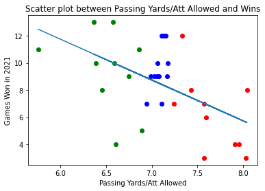

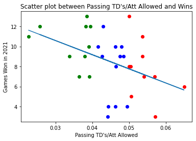

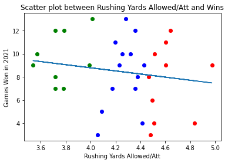

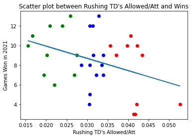

```python
col = []
for i in range(0, len(stats_df)):
    if stats_df['PassYds/Att'][i] <= 6.9:
        col.append('green')
    elif(stats_df['PassYds/Att'][i] >= 7.2):
        col.append('red')
    else:
        col.append('blue')
x = stats_df['PassYds/Att']
y = stats_df['W']
area = 40

for i in range(len(x)):
  plt.scatter(x[i], y[i], c = col[i], s = 50,
                linewidth = 0)
m, b = np.polyfit(x, y, 1)
plt.plot(x, m*x + b)
plt.title('Scatter plot between Passing Yards/Att Allowed and Wins')
plt.xlabel('Passing Yards/Att Allowed')
plt.ylabel('Games Won in 2021')
plt.show()


#Passing Touchdowns
col = []
for i in range(0, len(stats_df)):
    if stats_df['PassTD/Att'][i] <= .04:
        col.append('green')
    elif(stats_df['PassTD/Att'][i] >= .05):
        col.append('red')
    else:
        col.append('blue')
x = stats_df['PassTD/Att']
y = stats_df['W']
area = 40

for i in range(len(x)):
  plt.scatter(x[i], y[i], c = col[i], s = 50,
                linewidth = 0)
m, b = np.polyfit(x, y, 1)
plt.plot(x, m*x + b)
plt.title('Scatter plot between Passing TD\'s/Att Allowed and Wins')
plt.xlabel('Passing TD\'s/Att Allowed')
plt.ylabel('Games Won in 2021')
plt.show()

col = []
for i in range(0, len(stats_df)):
    if stats_df['RushYds/Att'][i] <= 4.05:
        col.append('green')
    elif(stats_df['RushYds/Att'][i] >= 4.45):
        col.append('red')
    else:
        col.append('blue')
x = stats_df['RushYds/Att']
y = stats_df['W']
area = 40

for i in range(len(x)):
  plt.scatter(x[i], y[i], c = col[i], s = 50,
                linewidth = 0)
m, b = np.polyfit(x, y, 1)
plt.plot(x, m*x + b)
plt.title('Scatter plot between Rushing Yards Allowed/Att and Wins')
plt.xlabel('Rushing Yards Allowed/Att')
plt.ylabel('Games Won in 2021')
plt.show()


col = []
for i in range(0, len(stats_df)):
    if stats_df['RushTD/Att'][i] <= .028:
        col.append('green')
    elif(stats_df['RushTD/Att'][i] >= .035):
        col.append('red')
    else:
        col.append('blue')
x = stats_df['RushTD/Att']
y = stats_df['W']
area = 40

for i in range(len(x)):
  plt.scatter(x[i], y[i], c = col[i], s = 50,
                linewidth = 0)
m, b = np.polyfit(x, y, 1)
plt.plot(x, m*x + b)
plt.title('Scatter plot between Rushing TD\'s Allowed/Att and Wins')
plt.xlabel('Rushing TD\'s Allowed/Att')
plt.ylabel('Games Won in 2021')
plt.show()
```

```python
x = stats_df['PassYds/Att']
y = stats_df['W-L%']
x = sm.add_constant(x)
result = sm.OLS(y, x).fit()
print(result.summary())


x = stats_df['PassTD/Att']
y = stats_df['W-L%']
x = sm.add_constant(x)
result = sm.OLS(y, x).fit()
print(result.summary())


x = stats_df['RushYds/Att']
y = stats_df['W-L%']
x = sm.add_constant(x)
result = sm.OLS(y, x).fit()
print(result.summary())



x = stats_df['RushTD/Att']
y = stats_df['W-L%']
x = sm.add_constant(x)
result = sm.OLS(y, x).fit()
print(result.summary())
```

```
                            OLS Regression Results
==============================================================================
Dep. Variable:                   W-L%   R-squared:                       0.281
Model:                            OLS   Adj. R-squared:                  0.257
Method:                 Least Squares   F-statistic:                     11.72
Date:                Mon, 16 May 2022   Prob (F-statistic):            0.00181
Time:                        19:56:58   Log-Likelihood:                 17.157
No. Observations:                  32   AIC:                            -30.31
Df Residuals:                      30   BIC:                            -27.38
Df Model:                           1
Covariance Type:            nonrobust
===============================================================================
                  coef    std err          t      P>|t|      [0.025      0.975]
-------------------------------------------------------------------------------
const           1.7299      0.360      4.803      0.000       0.994       2.465
PassYds/Att    -0.1735      0.051     -3.424      0.002      -0.277      -0.070
==============================================================================
Omnibus:                        0.501   Durbin-Watson:                   2.414
Prob(Omnibus):                  0.779   Jarque-Bera (JB):                0.484
Skew:                          -0.265   Prob(JB):                        0.785
Kurtosis:                       2.713   Cond. No.                         101.
==============================================================================

Warnings:
[1] Standard Errors assume that the covariance matrix of the errors is correctly specified.
                            OLS Regression Results
==============================================================================
Dep. Variable:                   W-L%   R-squared:                       0.180
Model:                            OLS   Adj. R-squared:                  0.153
Method:                 Least Squares   F-statistic:                     6.593
Date:                Mon, 16 May 2022   Prob (F-statistic):             0.0155
Time:                        19:56:58   Log-Likelihood:                 15.058
No. Observations:                  32   AIC:                            -26.12
Df Residuals:                      30   BIC:                            -23.18
Df Model:                           1
Covariance Type:            nonrobust
==============================================================================
                 coef    std err          t      P>|t|      [0.025      0.975]
------------------------------------------------------------------------------
const          0.8676      0.146      5.950      0.000       0.570       1.165
```

[output cut: 45 more lines]

```
Covariance Type:            nonrobust
==============================================================================
                 coef    std err          t      P>|t|      [0.025      0.975]
------------------------------------------------------------------------------
const          0.7290      0.110      6.650      0.000       0.505       0.953
RushTD/Att    -7.2119      3.334     -2.163      0.039     -14.021      -0.402
==============================================================================
Omnibus:                        4.485   Durbin-Watson:                   2.173
Prob(Omnibus):                  0.106   Jarque-Bera (JB):                1.729
Skew:                          -0.097   Prob(JB):                        0.421
Kurtosis:                       1.878   Cond. No.                         118.
==============================================================================

Warnings:
[1] Standard Errors assume that the covariance matrix of the errors is correctly specified.
```

### **Data Analysis Part 3**

```python
playoff_teams = stats_df[stats_df["Playoffs"] == 1]
non_playoff_teams = stats_df[stats_df["Playoffs"] == 0]
```

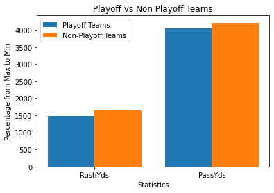

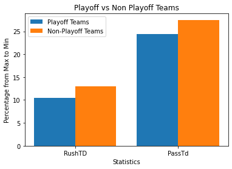

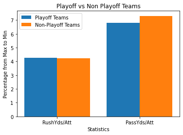

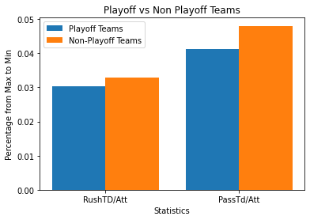

```python
X = ['RushYds','PassYds']
Playoff_Teams = [playoff_teams['RushYds'].mean(),playoff_teams['PassYds'].mean()]
Non_Playoff_Teams = [non_playoff_teams['RushYds'].mean(),non_playoff_teams['PassYds'].mean()]

X_axis = np.arange(len(X))

plt.bar(X_axis - 0.2, Playoff_Teams, 0.4, label = 'Playoff Teams')
plt.bar(X_axis + 0.2, Non_Playoff_Teams, 0.4, label = 'Non-Playoff Teams')

plt.xticks(X_axis, X)
plt.xlabel("Statistics")
plt.ylabel("Percentage from Max to Min")
plt.title("Playoff vs Non Playoff Teams")
plt.legend()
plt.show()


X = ['RushTD','PassTd']
Playoff_Teams = [playoff_teams['RushTD'].mean(),playoff_teams['PassTD'].mean()]
Non_Playoff_Teams = [non_playoff_teams['RushTD'].mean(),non_playoff_teams['PassTD'].mean()]

X_axis = np.arange(len(X))

plt.bar(X_axis - 0.2, Playoff_Teams, 0.4, label = 'Playoff Teams')
plt.bar(X_axis + 0.2, Non_Playoff_Teams, 0.4, label = 'Non-Playoff Teams')

plt.xticks(X_axis, X)
plt.xlabel("Statistics")
plt.ylabel("Percentage from Max to Min")
plt.title("Playoff vs Non Playoff Teams")
plt.legend()
plt.show()



X = ['RushYds/Att','PassYds/Att']
Playoff_Teams = [playoff_teams['RushYds/Att'].mean(),playoff_teams['PassYds/Att'].mean()]
Non_Playoff_Teams = [non_playoff_teams['RushYds/Att'].mean(),non_playoff_teams['PassYds/Att'].mean()]

X_axis = np.arange(len(X))

plt.bar(X_axis - 0.2, Playoff_Teams, 0.4, label = 'Playoff Teams')
plt.bar(X_axis + 0.2, Non_Playoff_Teams, 0.4, label = 'Non-Playoff Teams')

plt.xticks(X_axis, X)
plt.xlabel("Statistics")
plt.ylabel("Percentage from Max to Min")
plt.title("Playoff vs Non Playoff Teams")
plt.legend()
plt.show()


X = ['RushTD/Att','PassTd/Att']
Playoff_Teams = [playoff_teams['RushTD/Att'].mean(),playoff_teams['PassTD/Att'].mean()]
Non_Playoff_Teams = [non_playoff_teams['RushTD/Att'].mean(),non_playoff_teams['PassTD/Att'].mean()]

X_axis = np.arange(len(X))

plt.bar(X_axis - 0.2, Playoff_Teams, 0.4, label = 'Playoff Teams')
plt.bar(X_axis + 0.2, Non_Playoff_Teams, 0.4, label = 'Non-Playoff Teams')

plt.xticks(X_axis, X)
plt.xlabel("Statistics")
plt.ylabel("Percentage from Max to Min")
plt.title("Playoff vs Non Playoff Teams")
plt.legend()
plt.show()
```

Upon seeing the bar graphs comparing playoff teams and non playoff teams in each of the 8 statistics it becomes much clearer why stopping the run and stopping the pass are considered to be so integral to NFL teams. In 7 of the 8 statistics, all but Rush Yards per Attempt, the playoff teams were better at preventing the run or pass. This trend seems to indicate that despite some outliers if a team is better at stopping the run AND pass they are more likely to make the playoffs.